# Communicate Data Findings: Ford GoBike

## Data Analyst Nanodegree

- Binh Nguyen
- December 21, 2019

### 1. Introduction

### 2. Download data

### 3. Data Exploratory

### 4. Visualize Data

1. How the use rate of Ford GoBike?

2. What is riding pattern between Customer and Subscriber?

3. What is riding pattern between Customer and Subscriber?

4. What is duration ride between Customer and Subscriber?

5. Where are most used stations?

### 5. Summary

# 1. Introduction

[figure not shown]

- With increasing efforts to provide less-energy intensive and reduce carbon food print, sharing transportion seems a feasible option. Bike sharing in large metropolitans in US aims at the angle. Analyzing data of bike riding patterns provide some insights at data level, and some implications to imporove user experience and system management.
- In this report, we will explore dataset covers the [greater Bay Area](https://s3.amazonaws.com/baywheels-data/index.html) which includes the Downtown San Francisco, East Bay and San Jose . As of January of 2018, there is 2600 bicycles and 262 stations in [this area](https://en.wikipedia.org/wiki/Bay_Wheels). The Ford GoBike was acquired by Lyft and renamed to Bay Wheels in July 2019.
- The system of bike sharing aims at modern lifestyle with unclok and docking bike with a app on mobile phone. The new ebike design added to system and the "classic" bike is also kept operated [Lyft](https://www.lyft.com/bikes/bay-wheels/meet-our-bikes).
- Other cities has hosted bike-sharing, the available data can be found [here](https://github.com/BetaNYC/Bike-Share-Data-Best-Practices/wiki/Bike-Share-Data-Systems) and [here](https://www.bikeshare.com/data/)

# 2. Download data

```python
# download the cvs file. It will take 10-20 minutes and few hundreds MBs
for link in links_full:
    download_file(base_dir=base_dir,tmp_dir=zip_folder, url=link)
! ls /tmp/zipfiles/
```

```
2017-fordgobike-tripdata.csv	    201812-fordgobike-tripdata.csv.zip
201801-fordgobike-tripdata.csv.zip  201901-fordgobike-tripdata.csv.zip
201802-fordgobike-tripdata.csv.zip  201902-fordgobike-tripdata.csv.zip
201803-fordgobike-tripdata.csv.zip  201903-fordgobike-tripdata.csv.zip
201804-fordgobike-tripdata.csv.zip  201904-fordgobike-tripdata.csv.zip
201805-fordgobike-tripdata.csv.zip  201905-baywheels-tripdata.csv.zip
201806-fordgobike-tripdata.csv.zip  201906-baywheels-tripdata.csv.zip
201807-fordgobike-tripdata.csv.zip  201907-baywheels-tripdata.csv.zip
201808-fordgobike-tripdata.csv.zip  201908-baywheels-tripdata.csv.zip
201809-fordgobike-tripdata.csv.zip  201909-baywheels-tripdata.csv.zip
201810-fordgobike-tripdata.csv.zip  201910-baywheels-tripdata.csv.zip
201811-fordgobike-tripdata.csv.zip
```

```python
# this is a large file
# column structure looks fine
df.info()
```

```
<class 'pandas.core.frame.DataFrame'>
RangeIndex: 4554806 entries, 0 to 4554805
Data columns (total 13 columns):
duration_sec               int64
start_time                 object
end_time                   object
start_station_id           float64
start_station_name         object
start_station_latitude     float64
start_station_longitude    float64
end_station_id             float64
end_station_name           object
end_station_latitude       float64
end_station_longitude      float64
bike_id                    int64
user_type                  object
dtypes: float64(6), int64(2), object(5)
memory usage: 451.8+ MB
```

**Data structure:**

- About 4.5M rows and 13 columns
- Information included: using duration, start and end time, station name, id, coordinates, user type and bike id

**Interested questions**

- What is the use rate of each bike? This could help to determine if more bike is needed, and show a clear pattern of use rate?
- What the difference and similar of Customer and Subscriber riding patterns? The outcome helps nagivate the two class of customer and on the price model
- Where is most used location? This is useful to place the docking station for bikes

## 1. How the use rate of Ford GoBike?

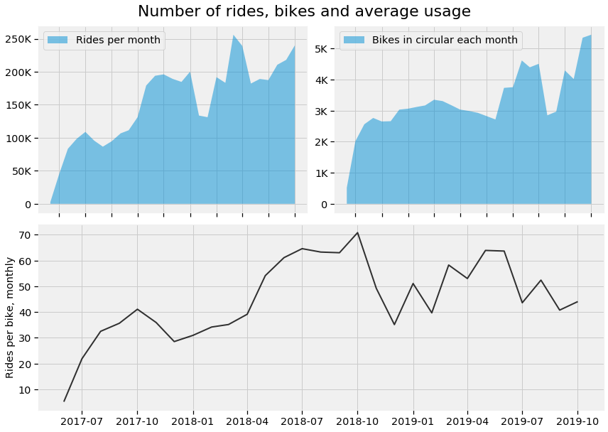

```python
fig = plt.figure(figsize=(12, 12))
gridsize = (3, 2)
fig.suptitle('Number of rides, bikes and average usage', y=0.70, fontsize=22)

ax1 = plt.subplot2grid(gridsize, (1, 0))
ax1.xaxis.set_ticklabels([])
ax1.stackplot(rides.index, rides.values, alpha=0.5)
ax1.yaxis.set_major_formatter(tick.FuncFormatter(transform_axis_fmt))
ax1.legend(labels=['Rides per month'], loc='upper left')

ax2 = plt.subplot2grid(gridsize, (1, 1))
ax2.xaxis.set_ticklabels([])
ax2.stackplot(bikes.index, bikes.values, alpha=0.5)
ax2.yaxis.set_major_formatter(tick.FuncFormatter(transform_axis_fmt))
ax2.legend(labels=['Bikes in circular each month'], loc='upper left')


ax3 = plt.subplot2grid(gridsize, (2, 0), colspan=2, rowspan=2)
plt.plot(ride_df.index, ride_df.values, alpha=0.8, c='black', linewidth=2);
ax3.set_ylabel('Rides per bike, monthly')
plt.tight_layout()
```

- Adoption rates shot up quickly around July- June 2017
- Summer time in SF has a higher use rate in compared the the winter in the same year

## 2. What is duration ride between Customer and Subscriber?

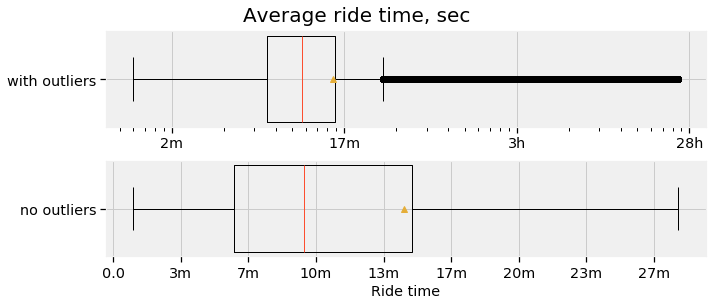

```python
# let have a look at the average ride time
fig, (ax1, ax2) = plt.subplots(ncols=1, nrows=2, figsize=(10,4), )
fig.suptitle('Average ride time, sec', y=1.05, fontsize=20)

ax1.boxplot(x=df.duration_sec, vert=False, widths=10, showmeans=True)
ax1.set_xscale('log')
ax1.xaxis.set_major_formatter(tick.FuncFormatter(transform_axis_fmt_time))
ax1.set_yticklabels(['with outliers']);

ax2.boxplot(x=df.duration_sec, vert=False, widths=10, showmeans=True, showfliers=False)
ax2.set_yticklabels(['no outliers']);
ax2.xaxis.set_major_formatter(tick.FuncFormatter(transform_axis_fmt_time))
ax2.set_xlabel('Ride time');
plt.tight_layout()
```

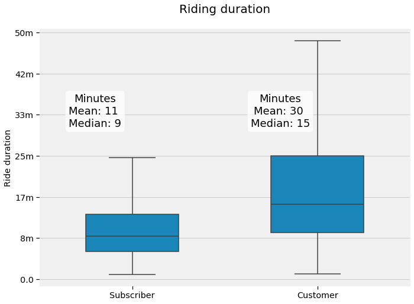

```python
# and how Customer and Subscriber ride duration looks like?
fig, ax = plt.subplots(figsize=(10,8))
ax = sns.boxplot(data=df, x='user_type', y='duration_sec',
                 color=base_color,showfliers=False,
                width=0.5)
ax.set_title('Riding duration', fontsize=20, y=1.05)
ax.set_xlabel('')
ax.yaxis.set_major_formatter(tick.FuncFormatter(transform_axis_fmt_time))
ax.set_ylabel('Ride duration');
plt.annotate(s_text, xy=(-.2, 17*2*60), xycoords="data", bbox=bbox_props, size=18, ha="center", va="center");
plt.annotate(c_text, xy=(0.8, 17*2*60), xycoords="data", bbox=bbox_props, size=18, ha="center", va="center");
```

```python
df.head()
```

| duration_sec | start_station_id | start_station_latitude | start_station_longitude | end_station_id | end_station_latitude | end_station_longitude | bike_id | m | h | dofw | distance | speed |
| --- | --- | --- | --- | --- | --- | --- | --- | --- | --- | --- | --- | --- |
| 66198 | 285.0 | 37.783521 | -122.431158 | 55.0 | 37.777053 | -122.429558 | 2186.0 | 8.0 | 18.0 | 3.0 | 0.733060 | 0.039865 |
| 66209 | 30.0 | 37.776598 | -122.395282 | 6.0 | 37.804770 | -122.403234 | 3343.0 | 7.0 | 18.0 | 2.0 | 3.210578 | 0.174570 |
| 66243 | 107.0 | 37.763015 | -122.426497 | 355.0 | 37.755367 | -122.388795 | 3392.0 | 9.0 | 17.0 | 5.0 | 3.422794 | 0.186013 |
| 66247 | 93.0 | 37.770407 | -122.391198 | 92.0 | 37.772301 | -122.393028 | 2790.0 | 5.0 | 15.0 | 6.0 | 0.264971 | 0.014399 |
| 66259 | 377.0 | 37.771917 | -122.453704 | 377.0 | 37.771917 | -122.453704 | 1488.0 | 2.0 | 15.0 | 6.0 | 0.000000 | 0.000000 |

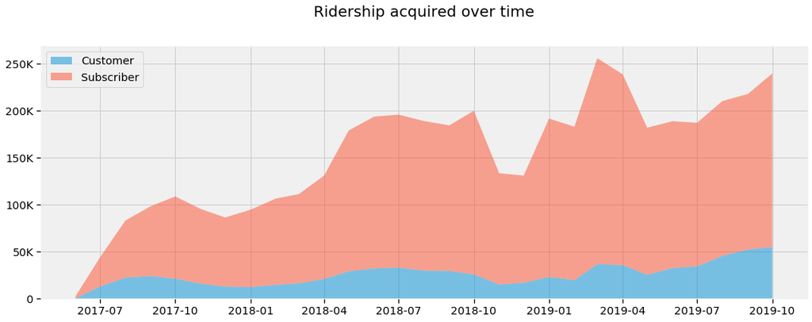

```python
# let look at number of Customer and Subsriber over time
plt.figure(figsize=(15,6))
plt.stackplot(users.index, users.Customer, users.Subscriber, alpha=0.5)
plt.title("Ridership acquired over time", fontsize=20, y=1.1)
plt.legend(['Customer', 'Subscriber'], loc='upper left')
ax = plt.gca()
ax.yaxis.set_major_formatter(tick.FuncFormatter(transform_axis_fmt))
plt.tight_layout()
```

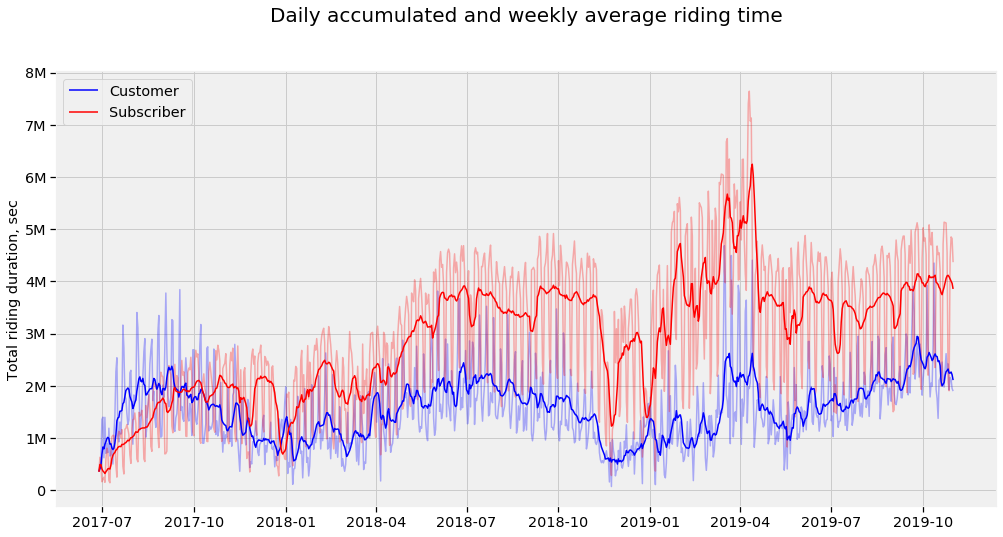

```python
fig, ax = plt.subplots(figsize=(15,8))
plt.title("Daily accumulated and weekly average riding time", fontsize=20, y=1.1)
ax.plot(dfsum.index, dfsum.Customer, alpha=0.3, c='blue')
ax.plot(dfsum.index, dfsum.Subscriber, alpha=0.3, c='red')
ax.plot(ma.index, ma.Customer, label='Customer', c='blue')
ax.plot(ma.index, ma.Subscriber, label='Subscriber',c='red' )
ax.yaxis.set_major_formatter(tick.FuncFormatter(transform_axis_fmt))
ax.legend(loc="upper left")
ax.set_ylabel('Total riding duration, sec');
# plt.yscale('log')
```

- interesting! based on [0pricing model](https://www.lyft.com/bikes/bay-wheels/pricing), Customer paid \$2 for 30-minute ride and Subscriber paid \$15 for 45-minute ride unlimited.
- Ford GoBike adopted by Customer at the early state which suggests the membership was not fully rolled out
- the total ride time of Subscribers are higher than Customers after early stage

## 3. What is riding pattern between Customer and Subscriber?

```python
xticks = ['M', 'T', 'W', 'Th', 'F', 'Sa', 'Su']
```

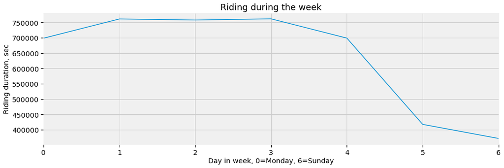

```python
# a quick look at number of rides in each day of weeks
# 0 = Monday, 6= Sunday
ax = df.groupby('dofw').size().plot(kind='line')
plt.xlabel("Day in week, 0=Monday, 6=Sunday")
plt.ylabel("Riding duration, sec")
plt.title("Riding during the week", fontsize=18);
```

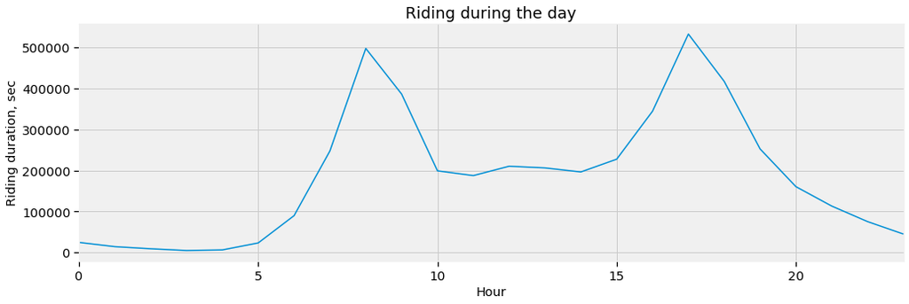

```python
# and during the day. It makes sense the bikes were used
# for short commutes
ax = df.groupby('h').size().plot(kind='line');
plt.xlabel("Hour")
plt.ylabel("Riding duration, sec")
plt.title("Riding during the day", fontsize=18);
```

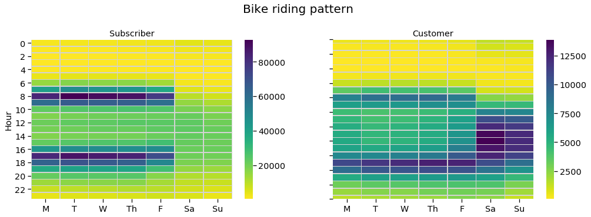

```python
fig, (ax1, ax2) = plt.subplots(ncols=2, sharey=True)
fig.suptitle('Bike riding pattern',y=1.05, fontsize=20)
ax1.set_title('Subscriber')
sns.heatmap(ax=ax1, data=dfss, cmap='viridis_r',
            linewidth=0.5, linecolor='lightgray', xticklabels=xticks)
plt.sca(ax1)
plt.yticks(rotation=0)

ax2.set_title('Customer')
sns.heatmap(ax=ax2, data=dfcc, cmap='viridis_r',
            linewidth=0.5, linecolor='lightgray', xticklabels=xticks)
ax2.set_ylabel('')
ax2.set_xlabel('')
ax1.set_xlabel('')
ax1.set_ylabel('Hour');
```

- Subsriber used bike for commutes
- Customers used bike for some commute, but mostly for visiting and pleasure in the weekends
- There are about 6 times more rides by Subscriber than Customers with the same color tone